# CADR_Monte_Carlo_Analysis_V7

This code is written to evaluate Equivalent Clean Air (ECA) flow rate, also called the clean air delivery rate (CADR), using two difefrent approaches.

The first approach is called log-linear approach that is conventionally used to evaluate ECA based on first-order decay assumption. The nex approach is called Integral approach which uses area under decay curve to estimate ECA.

First, we import all the needed python libraries.

```python
import numpy as np
from scipy import optimize
import matplotlib.pyplot as plt
from scipy import stats
```

Next, we have to import concentration dataset alongside its measurment errors, either manually or though reading from a file.

In the following setion, 8 different cases are provided as examples of concentration dataset. The examples used are as follows:

- Case #1: Ideal first order
- Case #2: Non-biological particle by Zeng et al. ([link](https://built-envi.com/wp-content/uploads/IIT-CADR-Testing-WINIX-5500-2-October-2021.pdf)).
- Case #3: Hypothetical E. Coli by Stephens et al. [link](https://www.ashrae.org/file%20library/technical%20resources/covid-19/20-31_stephens.pdf).
- Case #4-6: Bacteriophage MS2 by Ratliff et al. [doi](https://doi.org/10.1016/j.buildenv.2022.109804)
- Case #7: High res. VOC (formaldehyde) by Schumacher [doi](https://doi.org/10.3390/atmos15010109)
- Case #8: Low res. VOC (formaldehyde) by Law et al. [doi](https://doi.org/10.1016/j.buildenv.2024.111823)

# *Case #1: Ideal first order*

```python
t_c = np.array([0, 15, 30, 60, 90, 120])                                        # Time points
t_t = np.array([0, 15, 30, 60, 90, 120])                                        # Time points

num_simulations = 10000                                                         # Number of Monte Carlo simulations

c_test = np.array([ 8.00E+10, 2.29E+10, 6.57E+09,
                   5.39E+08, 4.42E+07, 3.63E+06])                               # Test concentrations (Ideal hypothetical first order)

c_control = np.array([8.00E+10, 4.28E+10, 2.29E+10,
                      6.57E+09, 1.88E+09, 5.39E+08])                            # Control concentrations (Ideal hypothetical first order)

c_test = np.log10(c_test)
c_control = np.log10(c_control)

c_bg_test=1                                                                     # If there is no background concentration, set to 0
c_bg_control=1
c_bg_test = np.log10(c_bg_test)
c_bg_control = np.log10(c_bg_control)



sigma_test = np.array([0,0,0,0,0,0])                                            # Test standard deviations (Ideal hypothetical first order)
sigma_control = np.array([0,0,0,0,0,0])                                         # Control standard deviations (Ideal hypothetical first order)
V = 3000                                                                        # Chamber volume (ft3) (Ideal hypothetical first order)
#V = 85                                                                         # Chamber volume (m3) (Ideal hypothetical first order)
```

# *Case #2: Real non-biological particles: Smoke (Truncated dataset)*

```python
num_simulations = 10000                                                         # Number of Monte Carlo simulations



t_t = np.array([0, 1, 2, 3, 4, 5, 6, 7, 8, 9, 10,
                11, 12, 13, 14, 15, 16, 17, 18, 19, 20, 21])                    # Time points

t_c = np.array([0, 1,	2, 3,	4, 5,	6, 7, 8, 9, 10,
                11,	12,	13,	14,	15, 16,	17,	18,	19,	20,	21])                    # Time points



c_control = np.array([46629.5822,	45262.5924,	38944.8016,	41968.5662,	39470.0741,
                   35389.2249,	37112.7987,	34422.0024,	33845.9813,	31813.524,
                   30782.9434,	29226.4405,	27259.9242,	27281.7278,	26790.9496,
                   25085.1379,	22133.3491,	22427.7312,	21338.2308,	18838.1459,
                   19229.6865,	19123.3036])                                    # Test concentrations (Ideal hypothetical first order)

c_control=np.log10(c_control)

c_test = np.array([20733.1887, 17199.744, 15496.7706, 13660.3969, 11310.3118,
                     10883.8787, 9122.8056, 8170.2825, 6648.0319, 6299.9989,
                     4945.4016, 4635.3165, 3815.3086,3194.0609, 2984.6603,
                     2455.5343, 2276.8268, 1918.0086, 1619.6262, 1389.2609,
                     1244.1919, 1231.9916])                                     # Control concentrations (Ideal hypothetical first order)
c_test=np.log10(c_test)


sigma_control = np.array([0., 0., 0., 0., 0., 0., 0., 0., 0.,
                          0., 0., 0., 0., 0., 0., 0., 0.,0., 0., 0., 0., 0.])

sigma_test = np.array([0., 0., 0., 0., 0., 0., 0., 0., 0., 0.,
                       0., 0., 0., 0., 0., 0., 0., 0., 0., 0., 0., 0.])



c_bg_test=113.7572667                                                           # If there is no background concentration, set to 0
c_bg_control=607.22006143
#c_bg_test = np.log10(c_bg_test)
#c_bg_control = np.log10(c_bg_control)

V = 1296.048                                                                    # Chamber volume (ft3) (Ideal hypothetical first order)
#V = 36.7                                                                       # Chamber volume (m3) (Ideal hypothetical first order)
```

# *Case #2: Real non-biological particles: Smoke (full dataset)*

```python
num_simulations = 10000                                                         # Number of Monte Carlo simulations

t_c = np.array([0, 1,	2,	3,	4,	5,	6,	7,	8,	9,	10,	11,	12,	13,	14,	15,
                16,	17,	18,	19,	20,	21,	22,	23,	24,	25,	26,	27,	28,	29,	30,	31,
                32,	33,	34,	35,	36,	37,	38,	39,	40,	41,	42,	43,	44,	45,	46,	47,
                48,	49,	50,	51,	52,	53,	54,	55,	56,	57,	58,	59])                # Time points'''




t_t = np.array([0, 1, 2, 3, 4, 5, 6, 7, 8, 9, 10,
                11, 12, 13, 14, 15, 16, 17, 18, 19, 20, 21])                    # Time points

c_control = np.array([46629.5822,	45262.5924,	38944.8016,	41968.5662,	39470.0741,
                   35389.2249,	37112.7987,	34422.0024,	33845.9813,	31813.524,
                   30782.9434,	29226.4405,	27259.9242,	27281.7278,	26790.9496,
                   25085.1379,	22133.3491,	22427.7312,	21338.2308,	18838.1459,
                   19229.6865,	19123.3036,	18965.1773,	17917.88,	16800.8839,
                   17120.304,	15590.7547,	15133.0791,	14335.7846,	14481.8507,
                   13082.9319,	13615.1729,	12671.266,	12284.8735,	12212.7403,
                   10803.6982,	10626.2898,	9913.9165,	9592.189,	9748.4621,
                   9832.5099,	8845.3218,	8723.0745,	8549.6231,	7938.6471,
                   7994.5961,	7957.8449,	7420.9003,	7394.3616,	6939.229,
                   6480.9155,	6413.2256,	6032.8,	6506.7329,	5738.9208,
                   5651.0126,	5511.8419,	5562.7665,	5061.1998,	5221.2187])   # Test concentrations (Ideal hypothetical first order)'''


c_control=np.log10(c_control)

c_test = np.array([20733.1887, 17199.744, 15496.7706, 13660.3969, 11310.3118,
                     10883.8787, 9122.8056, 8170.2825, 6648.0319, 6299.9989,
                     4945.4016, 4635.3165, 3815.3086,3194.0609, 2984.6603,
                     2455.5343, 2276.8268, 1918.0086, 1619.6262, 1389.2609,
                     1244.1919, 1231.9916])                                     # Control concentrations (Ideal hypothetical first order)
c_test=np.log10(c_test)

sigma_control = np.array([0., 0., 0., 0., 0., 0., 0., 0., 0., 0., 0., 0., 0., 0., 0., 0., 0.,
                       0., 0., 0., 0., 0., 0., 0., 0., 0., 0., 0., 0., 0., 0., 0., 0., 0.,
                       0., 0., 0., 0., 0., 0., 0., 0., 0., 0., 0., 0., 0., 0., 0., 0., 0.,
                       0., 0., 0., 0., 0., 0., 0., 0., 0.])                     # Test standard deviations (Ideal hypothetical first order)'''


sigma_test = np.array([0., 0., 0., 0., 0., 0., 0., 0., 0., 0., 0., 0., 0., 0., 0., 0., 0.,
                      0., 0., 0., 0., 0.])



c_bg_test=113.7572667                                                           # If there is no background concentration, set to 0
c_bg_control=607.22006143

#c_bg_test = np.log10(c_bg_test)
#c_bg_control = np.log10(c_bg_control)                                          # Control standard deviations (Ideal hypothetical first order)
V = 1296.048                                                                    # Chamber volume (ft3) (Ideal hypothetical first order)
#V = NA                                                                         # Chamber volume (m3) (Ideal hypothetical first order)
```

# *Case #3: Hypothetical E.Coli*

```python
t_c = np.array([0, 15, 30, 45, 60 ])                                            # Time points
t_t = np.array([0, 15, 30, 45, 60 ])                                            # Time points


c_test = np.array([5000, 2700, 1200, 400, 100])                                 # Test concentrations (Ideal hypothetical first order)
c_control = np.array([5000, 4200, 3000,2700, 2000])                             # Control concentrations (Ideal hypothetical first order)
c_test = np.log10(c_test)
c_control = np.log10(c_control)

c_bg_test=1                                                                     # If there is no background concentration, set to 0
c_bg_control=1
c_bg_test = np.log10(c_bg_test)
c_bg_control = np.log10(c_bg_control)


sigma_test = np.array([0,0,0,0,0])                                              # Test standard deviations (Ideal hypothetical first order)
sigma_control = np.array([0,0,0,0,0])                                           # Control standard deviations (Ideal hypothetical first order)
V = 500                                                                         # Chamber volume (ft3) (Ideal hypothetical first order)
#V = 14.2                                                                       # Chamber volume (m3) (Ideal hypothetical first order)
```

# *Case #4: Ratliff et al BPI*

```python
t_c = np.array([0, 15, 30, 60, 90 ,120, 1200])                                  # Time points
t_t = np.array([0, 15, 30, 60, 90 ,120, 1200])                                  # Time points

c_test = np.array([8.46, 7.63, 7.22, 6.21, 5.89, 5.64, 10**0.1 ])               # Test concentrations (Ratliff BPI)
c_control = np.array([8.47, 7.68, 7.16, 7.09, 6.21, 6.10, 10**0.1 ])            # Control concentrations (Ratliff BPI)

sigma_test = np.array([0.000001, 0.24 ,0.51 ,0.52 ,0.53 ,0.5, 0])                   # Test standard deviations (ratliff values)
sigma_control = np.array([0.000001 ,0.36, 0.39, 0.3, 0.36, 0.49, 0])                 # Control standard deviations (ratliff values)



c_bg_test=0                                                                     # If there is no background concentration, set to 0
c_bg_control=0


V = 3000                                                                        # Chamber volume (ft3)
#V = 85                                                                         # Chamber volume (m3)
```

# *Case #5: Ratliff et al PCO1*

```python
t_c = np.array([0, 15, 30, 60, 90])                                             # Time points
t_t = np.array([0, 15, 30, 60, 90])                                             # Time points



c_test = np.array([ 8.11212724060371, 7.589987734, 6.745802232,
                   6.013936402, 5.394571206 ])                                  # Test concentrations

c_control = np.array([8.46745953764963, 7.684595602, 7.163725729,
                      7.086631702, 6.211568868])                                # Control concentrations


sigma_test = np.array([	0.108808569398572, 0.254108644,	0.169662969,
                       0.262771866,	0.047624259])                               # Test standard deviations

sigma_control = np.array([	0.237966029977382, 0.358965447,	0.393189888,
                          0.301479043,	0.361953917])                           # Control standard deviations



c_bg_test=0                                                                     # If there is no background concentration, set to 0
c_bg_control=0

V = 3000                                                                        # Chamber volume (ft3)
#V = 85                                                                         # Chamber volume (m3)
```

# *Case #6: Ratliff et al PCO2*

```python
t_c = np.array([0, 15, 30, 60, 90])                                             # Time points
t_t = np.array([0, 15, 30, 60, 90])                                             # Time points
c_test = np.array([8.032891171, 7.087704857, 6.424694684,
                   5.320557829, 4.709637767])                                   # Test concentrations

c_control = np.array([8.467459538, 7.684595602, 7.163725729,
                      7.086631702, 6.211568868])                                # Control concentrations

sigma_test = np.array([0.033101768,	0.029661622,	0.219839957,
                       0.117283171,	0.129724927])                               # Test standard deviations

sigma_control = np.array([0.23796603,	0.358965447,	0.393189888,
                          0.301479043,	0.361953917])                           # Control standard deviations



c_bg_test=0                                                                     # If there is no background concentration, set to 0
c_bg_control=0

V = 3000                                                                        # Chamber volume (ft3)
#V = 85                                                                         # Chamber volume (m3)
```

# *Case #7: Real VOC (High Resolution) (Schumacher et. al. 2024)*

```python
# full dataset

t_c = np.array([0, 1,	2,	3,	4,	5,	6,	7,	8,	9,	10,
                11,	12,	13,	14,	15, 16,	17,	18,	19,	20,
                21,	22,	23,	24,	25,	26,	27,	28,	29,	30,
                31, 32,	33,	34,	35,	36,	37,	38,	39,	40,
                41,	42,	43,	44,	45,	46,	47, 48,	49,	50,
                51,	52,	53,	54,	55,	56,	57,	58,	59, 60])                        # Time points

t_t = np.array([0, 1,	2,	3,	4,	5,	6,	7,	8,	9,	10,
                11,	12,	13,	14,	15, 16,	17,	18,	19,	20,
                21,	22,	23,	24,	25,	26,	27,	28,	29,	30,
                31, 32,	33,	34,	35,	36,	37,	38,	39,	40,
                41,	42,	43,	44,	45,	46,	47, 48,	49,	50,
                51,	52,	53,	54,	55,	56,	57,	58,	59, 60])                        # Time points



c_test = np.array([833.75, 761.28, 658.93, 567.20, 499.72, 451.38, 422.54,
377.29, 321.06, 295.83, 223.47, 192.89, 168.51, 180.00, 154.03, 117.60, 114.59,
94.81, 86.12, 74.05, 65.78, 61.08, 55.48, 51.09, 47.80, 43.67, 38.95, 35.24,
32.66, 30.53, 28.45, 26.76, 27.44, 29.12, 23.70, 24.67, 21.88, 19.60, 18.40,
17.51, 19.38, 19.07, 16.17, 14.67, 13.91, 13.55, 12.91, 12.21, 11.86, 12.43,
12.45, 12.32, 11.57, 11.21, 11.55, 10.61, 10.93, 11.39, 11.73, 11.32, 11.30 ])

c_test = np.log10(c_test)
c_control = np.array([929.45, 951.57, 923.26, 906.75, 912.08, 933.73, 915.11,
904.99, 891.02, 898.66, 899.28, 881.89, 880.40, 889.34, 888.76, 896.80, 891.25,
880.13, 870.49, 862.30, 862.03, 866.09, 874.08, 864.19, 880.57, 872.92, 861.04,
856.26, 862.26, 863.67, 843.84, 844.73, 842.50, 838.72, 844.15, 843.70, 855.47,
834.44, 830.98, 823.93, 822.37, 825.25, 848.16, 812.26, 885.45, 863.72, 826.80,
833.43, 822.13, 809.45, 806.02, 800.97, 801.26, 795.55, 836.46, 827.70, 785.76,
786.31, 786.06, 851.69, 837.34])                                                     # Control concentrations (Ideal hypothetical first order)

c_control = np.log10(c_control)
sigma_test = np.array([0, 0, 0, 0, 0, 0, 0, 0, 0, 0,
                       0, 0, 0, 0, 0, 0, 0, 0, 0, 0,
                       0, 0, 0, 0, 0, 0, 0, 0, 0, 0,
                       0, 0, 0, 0, 0, 0, 0, 0, 0, 0,
                       0, 0, 0, 0, 0, 0, 0, 0, 0, 0,
                       0, 0, 0, 0, 0, 0, 0, 0, 0, 0,
                       0])                                                      # Test standard deviations (Ideal hypothetical first order)


sigma_control = np.array([0, 0, 0, 0, 0, 0, 0, 0, 0, 0,
                         0, 0, 0, 0, 0, 0, 0, 0, 0, 0,
                         0, 0, 0, 0, 0, 0, 0, 0, 0, 0,
                         0, 0, 0, 0, 0, 0, 0, 0, 0, 0,
                         0, 0, 0, 0, 0, 0, 0, 0, 0, 0,
                         0, 0, 0, 0, 0, 0, 0, 0, 0, 0,
                         0])                                                    # Test standard deviations (Ideal hypothetical first order)

c_bg_test=9.66                                                                     # If there is no background concentration, set to 0
c_bg_control=250
#c_bg_test = np.log10(c_bg_test)
#c_bg_control = np.log10(c_bg_control)

V = 1034.72                                                                     # Chamber volume (ft3) (Ideal hypothetical first order)
#V = 29.3                                                                       # Chamber volume (m3) (Ideal hypothetical first order)
```

# Case #8: Law et al 2024 (truncated dataset)

```python
#0-40 minutes for control and 0-25 minutes for test

t_t = np.array([0, 5, 10, 15, 20, 25])                                          # Time points
t_c = np.array([0, 5, 10, 15, 20, 25, 30, 35, 40 ])                             # Time points


c_test = np.array([0.958783047,	0.502557891,	0.40034575,
                   0.332838565,	0.301776099,	0.272451193])                     # Test concentrations

c_control = np.array([0.972665911, 0.969369171, 0.959128797, 0.959302774,
                      0.95947675, 0.950973937, 0.949412555, 0.940911944,
                      0.941083718])                                             # Control concentrations

sigma_test = np.array([0, 0, 0, 0, 0, 0 ])                                      # Test standard deviations
sigma_control = np.array([0, 0, 0, 0, 0, 0, 0, 0, 0])                           # Control standard deviations

c_test = np.log10(c_test)
c_control=np.log10(c_control)


c_bg_test=0.24                                                                  # If there is no background concentration, set to 0
c_bg_control=0.65


V = 1059.44174                                                                                                                                          # Chamber volume (ft3)
#V = 30                                                                                                                                             # Chamber volume (m3)
```

# Case #8: Law et al 2024 (Full datset)

```python
t_c = np.array([0, 5, 10, 15, 20, 25, 30, 35, 40, 45, 50, 55, 60])              # Time points
t_t = np.array([0, 5, 10, 15, 20, 25, 30, 35, 40, 45, 50, 55, 60])              # Time points


#0-60 minutes dataset (full dataset)

c_test = np.array([0.958783047, 0.502557891, 0.40034575, 0.332838565,
                   0.301776099, 0.272451193, 0.272625169, 0.251974851,
                   0.262558772, 0.262730546, 0.252494577, 0.252666351,
                   0.24242818 ])                                                # Test concentrations

c_test=np.log10(c_test)

c_control = np.array([0.972665911, 0.969369171, 0.959128797, 0.959302774,
                      0.95947675, 0.950973937, 0.949412555, 0.940911944,
                      0.941083718, 0.910021252, 0.910193026, 0.899954854,
                      0.901861986])                                             # Control concentrations

c_control=np.log10(c_control)

sigma_control = np.array([0, 0, 0, 0, 0, 0, 0, 0, 0, 0, 0, 0, 0])               # Control standard deviations
sigma_test    = np.array([0, 0, 0, 0, 0, 0, 0, 0, 0, 0, 0, 0, 0 ])              # Test standard deviations


c_bg_test=0.24                                                                  # If there is no background concentration, set to 0
c_bg_control=0.65

V = 1059.44174                                                                  # Chamber volume (ft3)
#V = 30                                                                         # Chamber volume (m3)
```

# **Monte Carlo Analysis**

## 1- First-order decay method:

The loss rate has been calculated based on the following formula

$$K = \frac{\sum_{i=0}^{np} t_i \ln\left(\frac{C_i-C_bg}{C_0-C_bg }\right)}{\sum_{i=0}^{np} t_i^2}$$

Then, loss rates will be pplugged into the CADR formula to obtain value for CADR

$$CADR=V(K_{Test}-K_{Control})$$

```
Original CADR value = 116.90209908956523

Mean CADR value from Monte Carlo simulations = 116.90209908956517

Standard deviation of CADR value from Monte Carlo simulations = 5.684341886080802e-14

Error = 4.862480597312211e-14%
```

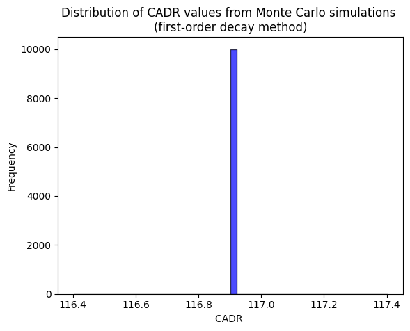

```python
num_simulations = 10000
# Function to compute the CADR component for either test or control
def compute_component(t, c, c_bg):
    #print((c / c[0]))
    ln_c_ratio = -np.log((10**c-c_bg) / (10**c[0]-c_bg))

    numerator = np.sum((t * ln_c_ratio) )
    denominator = np.sum((t ** 2) )

    return (numerator / denominator)

# Original CADR value
CADR_original = V * (compute_component(t_t, c_test, c_bg_test) - compute_component(t_c, c_control, c_bg_control))
print(f"Original CADR value = {CADR_original}","\n")


# Monte Carlo simulations
CADR_values = np.zeros(num_simulations)

for i in range(num_simulations):
    c_test_simulated = np.random.normal((c_test), (sigma_test/3))
    c_control_simulated = np.random.normal((c_control),(sigma_control/3))
    CADR_values[i] = V * (compute_component(t_t, c_test_simulated, c_bg_test) - compute_component(t_c, c_control_simulated, c_bg_control))

# Calculate mean and standard deviation of CADR
CADR_mean = np.mean(CADR_values)
CADR_std = np.std(CADR_values)

print(f"Mean CADR value from Monte Carlo simulations = {CADR_mean}","\n")
print(f"Standard deviation of CADR value from Monte Carlo simulations = {CADR_std}","\n")
print(f"Error = {100*CADR_std/CADR_mean}%","\n")

# Plotting the distribution of CADR values
plt.hist(CADR_values, bins=50, alpha=0.7, color='b', edgecolor='black')
plt.title('Distribution of CADR values from Monte Carlo simulations \n(first-order decay method)')
plt.xlabel('CADR ')
plt.ylabel('Frequency')

# Disable scientific notation for x-axis and y-axis
plt.ticklabel_format(style='plain', axis='x')
plt.ticklabel_format(style='plain', axis='y')

# Optionally, adjust the format of the ticks
from matplotlib.ticker import ScalarFormatter
plt.gca().xaxis.set_major_formatter(ScalarFormatter(useOffset=False))
plt.gca().yaxis.set_major_formatter(ScalarFormatter(useOffset=False))

plt.show()
```

The CADR base on the integral method can be calculated as follows:

$$ \text{CADR}_{\text{Integral}} = \frac{\text{VC}_{\text{test}}(0)}{\int_{0}^{\infty} (C_{\text{test}}(t)-C_{bg, control}) \, dt} - \frac{\text{VC}_{\text{control}}(0)}{\int_{0}^{\infty}( C_{\text{control}}(t)-C_{bg, control}) \, dt} $$

Where the integral in the denominator can be calculated using either trapezoidal or logarithmic trapezoidal method. here, we use logarithmic trapezoidal method which looks like the following:

$$ \int_{0}^{\infty} C(t) \, dt = \sum_{n=1}^{\infty} \left( \frac{t_i - t_{i-1}}{\ln\left( \frac{C(t_{i-1})-C_{bg}}{C(t_i)-C_{bg} } \right)} \left( C(t_{i-1}) - C(t_i) \right) \right) $$

```
test 0.1272083774282268
control 0.025499043930522245
Original CADR value = 105.24068155674486

Mean CADR value from Monte Carlo simulations = 105.24068155674486

Standard deviation of CADR value from Monte Carlo simulations = 0.0

Error = 0.0%
```

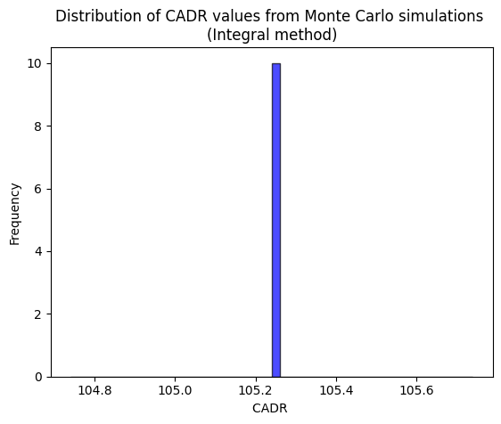

```python
import numpy as np
import matplotlib.pyplot as plt

num_simulations = 10
# Function to compute the integral
def compute_integral(t, c, c_bg):
    N = len(t)
    integral_sum = 0.0

    for i in range(1, N):

        t_diff = t[i] - t[i-1]
        ln_c_ratio = np.log((10**c[i-1]-c_bg) / (10**c[i]-c_bg))
        #print(ln_c_ratio)
        c_diff = 10**c[i-1] - 10**c[i]
        integral_sum += (t_diff / ln_c_ratio) * c_diff
    #print(integral_sum)
    return integral_sum

# Function to compute the CADR component for either test or control
def compute_component(t, c, c_bg):

    integral_c = compute_integral(t, c, c_bg)
    #print(integral_c)
    return (10**c[0]) / integral_c


# Original CADR value
CADR_original = V* (compute_component(t_t, c_test, c_bg_test) - compute_component(t_c, c_control, c_bg_control))

print("test",compute_component(t_t, c_test, c_bg_test))
print("control",compute_component(t_c, c_control, c_bg_control))
print(f"Original CADR value = {CADR_original}\n")

# Monte Carlo simulations
CADR_values = np.zeros(num_simulations)
'''
for i in range(num_simulations):
    c_test_simulated = np.random.normal(c_test, sigma_test)
    plt.plot(t_t, c_test_simulated)
    c_control_simulated = np.random.normal(c_control, sigma_control)
    plt.plot(t_c, c_control_simulated)

    CADR_values[i] = V* (compute_component(t_t, c_test_simulated) - compute_component(t_c, c_control_simulated))
#print(CADR_values)
plt.show()
'''

#fig, (ax1, ax2) = plt.subplots(1, 2, figsize=(14, 6))

for i in range(num_simulations):
    c_test_simulated = np.random.normal(c_test, sigma_test/3)
    c_control_simulated = np.random.normal(c_control, sigma_control/3)

    #ax1.plot(t_t, c_test_simulated, alpha=0.1)
    #ax2.plot(t_c, c_control_simulated, alpha=0.1)

    CADR_values[i] = V * (compute_component(t_t, c_test_simulated, c_bg_test) - compute_component(t_c, c_control_simulated, c_bg_control))
# Customize plots
'''
ax1.set_title('Test Simulations')
ax1.set_xlabel('Time')
ax1.set_ylabel('Concentration')

ax2.set_title('Control Simulations')
ax2.set_xlabel('Time')
ax2.set_ylabel('Concentration')

plt.tight_layout()
plt.show()
'''
# Print CADR values if needed
# print(CADR_values)


# Calculate mean and standard deviation of CADR
CADR_mean = np.mean(CADR_values)
CADR_std = np.std(CADR_values)

print(f"Mean CADR value from Monte Carlo simulations = {CADR_mean}\n")
print(f"Standard deviation of CADR value from Monte Carlo simulations = {CADR_std}\n")
print(f"Error = {CADR_std / CADR_mean * 100}%\n")

# Plotting the distribution of CADR values
plt.hist(CADR_values, bins=50, alpha=0.7, color='b', edgecolor='black')
plt.title('Distribution of CADR values from Monte Carlo simulations \n(Integral method)')
plt.xlabel('CADR ')
plt.ylabel('Frequency')

# Disable scientific notation for x-axis and y-axis
plt.ticklabel_format(style='plain', axis='x')
plt.ticklabel_format(style='plain', axis='y')

# Optionally, adjust the format of the ticks
from matplotlib.ticker import ScalarFormatter
plt.gca().xaxis.set_major_formatter(ScalarFormatter(useOffset=False))
plt.gca().yaxis.set_major_formatter(ScalarFormatter(useOffset=False))

plt.show()
```

```
Mean k1 value for test from Monte Carlo simulations = 0.12891970374259107

Standard deviation of k1 value for test from Monte Carlo simulations = 2.7755575615628914e-17

Mean k1 value for control from Monte Carlo simulations = 0.0026821435337412926

Standard deviation of k1 value for control from Monte Carlo simulations = 4.336808689942018e-19

Mean k2 value for test from Monte Carlo simulations = 0.005654409953692421

Standard deviation of k2 value for test from Monte Carlo simulations = 8.673617379884035e-19

Mean k2 value for control from Monte Carlo simulations = 0.0001176333295346026

Standard deviation of k2 value for control from Monte Carlo simulations = 4.0657581468206416e-20
```

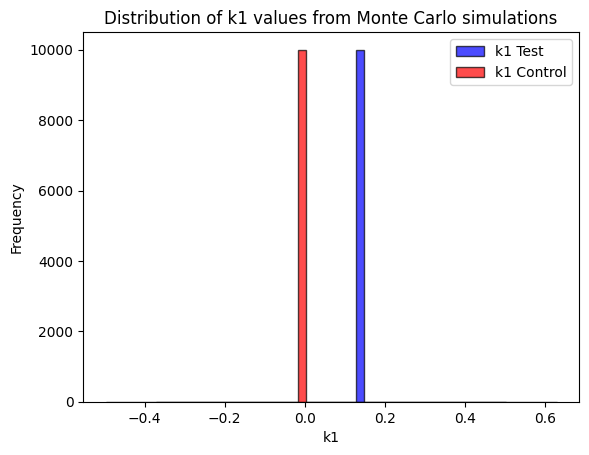

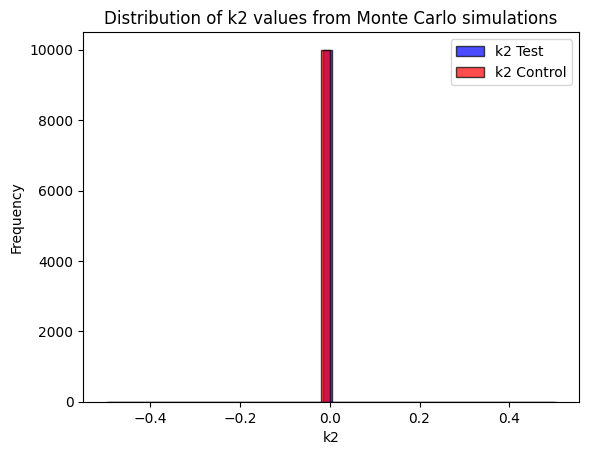

```python
import numpy as np
import matplotlib.pyplot as plt
from scipy.stats import t
from scipy import stats
num_simulations = 10000

# Define the compute_k1 function using the first part of the new formula
def compute_k1(t, c,c_bg):
    ln_c_ratio = -np.log((10**c-c_bg) / (10**c[0]-c_bg))
    numerator = np.sum(t * ln_c_ratio)
    denominator = np.sum(t ** 2)
    return numerator / denominator

# Define the compute_k2 function using the second part of the new formula
def compute_k2(t, c, k,c_bg, alpha=0.05):
    ln_c_ratio = -np.log((10**c-c_bg) / (10**c[0]-c_bg))

    # Calculate the mean of the time points
    t_mean = np.mean(t)

    # Calculate the second term
    residual_sum = np.sum(((ln_c_ratio - k * t)) ** 2)
    #print( k)
    critical_value = stats.t.ppf(1- alpha / 2, len(t) - 1)
    #second_term = critical_value * np.sqrt(residual_sum / ((len(t) - 1) * np.sum((t) ** 2)))
    second_term = np.sqrt(residual_sum / ((len(t) - 1) * np.sum((t) ** 2)))

    return second_term


# Monte Carlo simulations for the first formula


k1_values_test = np.zeros(num_simulations)
k1_values_control = np.zeros(num_simulations)

for i in range(num_simulations):
    c_test_simulated = np.random.normal(c_test, sigma_test / 3)
    c_control_simulated = np.random.normal(c_control, sigma_control / 3)
    k1_values_test[i] = compute_k1(t_t, c_test_simulated,c_bg_test)
    k1_values_control[i] = compute_k1(t_c, c_control_simulated, c_bg_control)

# Monte Carlo simulations for the second formula
k2_values_test = np.zeros(num_simulations)
k2_values_control = np.zeros(num_simulations)

for i in range(num_simulations):
    c_test_simulated = np.random.normal(c_test, sigma_test / 3)
    c_control_simulated = np.random.normal(c_control, sigma_control / 3)
    k_test = compute_k1(t_t, c_test_simulated, c_bg_test)
    k_control = compute_k1(t_c, c_control_simulated, c_bg_control)
    k2_values_test[i] = compute_k2(t_t, c_test_simulated, k_test, c_bg_test)
    k2_values_control[i] = compute_k2(t_c, c_control_simulated, k_control, c_bg_control)

# Calculate mean and standard deviation for both formulas
k1_mean_test = np.mean(k1_values_test)
k1_std_test = np.std(k1_values_test)
k1_mean_control = np.mean(k1_values_control)
k1_std_control = np.std(k1_values_control)

k2_mean_test = np.mean(k2_values_test)
k2_std_test = np.std(k2_values_test)
k2_mean_control = np.mean(k2_values_control)
k2_std_control = np.std(k2_values_control)

print(f"Mean k1 value for test from Monte Carlo simulations = {k1_mean_test}\n")
print(f"Standard deviation of k1 value for test from Monte Carlo simulations = {k1_std_test}\n")
print(f"Mean k1 value for control from Monte Carlo simulations = {k1_mean_control}\n")
print(f"Standard deviation of k1 value for control from Monte Carlo simulations = {k1_std_control}\n")

print(f"Mean k2 value for test from Monte Carlo simulations = {k2_mean_test}\n")
print(f"Standard deviation of k2 value for test from Monte Carlo simulations = {k2_std_test}\n")
print(f"Mean k2 value for control from Monte Carlo simulations = {k2_mean_control}\n")
print(f"Standard deviation of k2 value for control from Monte Carlo simulations = {k2_std_control}\n")

# Plotting the distribution of k1 values
plt.hist(k1_values_test, bins=50, alpha=0.7, color='b', edgecolor='black', label='k1 Test')
plt.hist(k1_values_control, bins=50, alpha=0.7, color='r', edgecolor='black', label='k1 Control')
plt.title('Distribution of k1 values from Monte Carlo simulations')
plt.xlabel('k1')
plt.ylabel('Frequency')
plt.legend()
plt.show()

# Plotting the distribution of k2 values
plt.hist(k2_values_test, bins=50, alpha=0.7, color='b', edgecolor='black', label='k2 Test')
plt.hist(k2_values_control, bins=50, alpha=0.7, color='r', edgecolor='black', label='k2 Control')
plt.title('Distribution of k2 values from Monte Carlo simulations')
plt.xlabel('k2')
plt.ylabel('Frequency')
plt.legend()
plt.show()
```